# Antelope Project Analysis

Andrea Stocco

April 29, 2020

# Behavioral Data

## Demographics

First, let’s load the data and transform it into a Wide format table

```r
behav <- read_tsv("data/behav/behav_data.txt",
                  col_types=cols())

behav$material[behav$material=="Swahili"] <- "Vocabulary"
behav$material[behav$material=="US Maps"] <- "Maps"

behav <- behav %>% rename(Gender = gender, Age = age)

wbehav <- behav %>% pivot_wider(values_from = alpha,
                                id_cols = c(Subject, Gender, Age),
                                names_from = material)
```

At this point, we can look at the participant demographocs

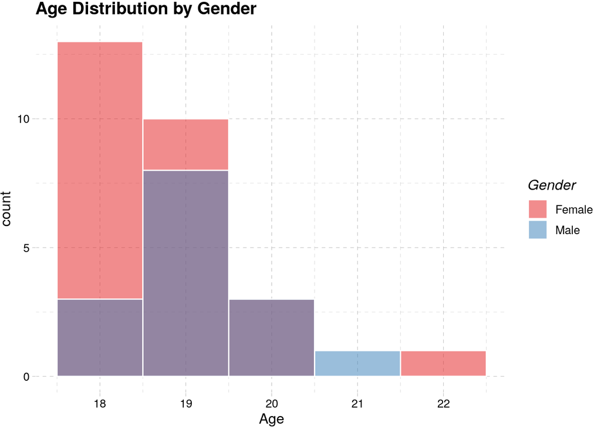

```r
ggplot(data=wbehav, aes(x=Age, col=Gender)) +
  geom_histogram(aes(col="white", fill=Gender),
                 colour="white", alpha=0.5,
                 position="identity", binwidth = 1) +
  scale_color_brewer(palette = "Set1") +
  scale_fill_brewer(palette = "Set1") +
  ggtitle("Age Distribution by Gender") +
  theme_pander()
```

## Rate of Forgetting (Alpha parameter) for the two tasks

We can now examine the distribution and correlation of the rate of forgetting for the verbal (Vocabulary) and Maps:

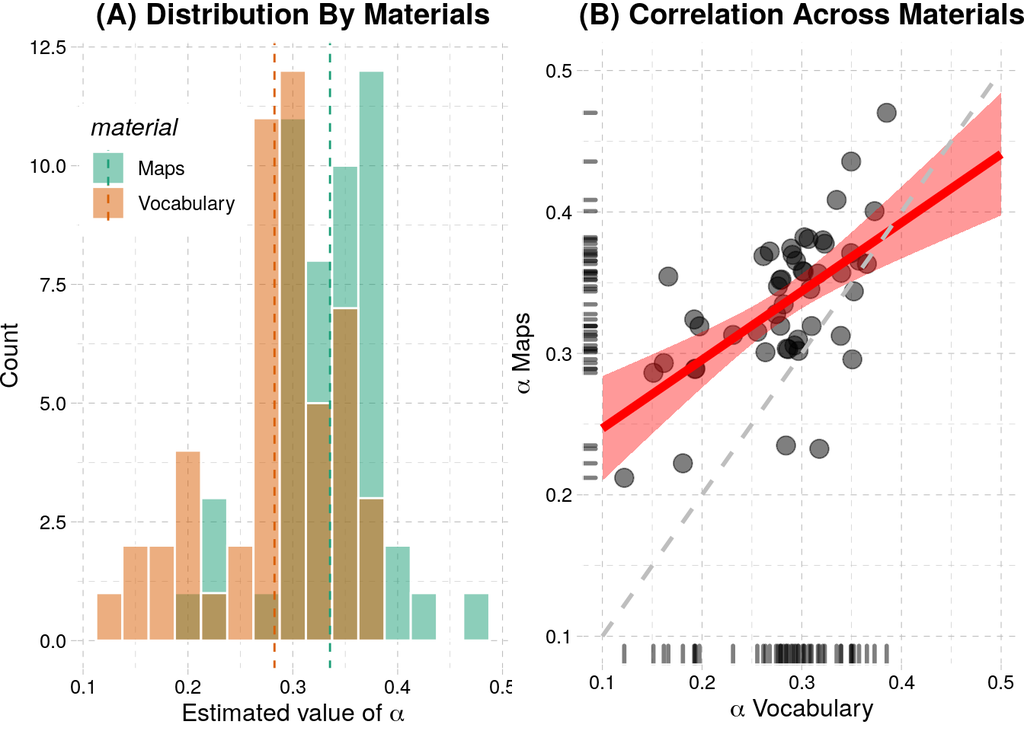

```r
mu <- behav %>%
  group_by(material) %>%
  summarize(alpha=mean(alpha))

p1 <- ggplot(behav, aes(x=alpha, fill=material)) +
  geom_histogram(col="white", binwidth = 0.025,
                 alpha=0.5, position="identity") +
  scale_color_brewer(palette = "Dark2") +
  scale_fill_brewer(palette = "Dark2") +
  geom_vline(data=mu, aes(xintercept=alpha, color=material),
             linetype="dashed") +
  xlab(expression(paste("Estimated value of ", alpha))) +
  theme_pander() +
  ylab("Count") +
  ggtitle("(A) Distribution By Materials") +
  theme(legend.position = c(0.2, 0.8)) +
  theme(plot.title = element_text(hjust = 0.5))

p2 <- ggplot(wbehav, aes(x=Vocabulary, y=Maps)) +
  geom_point(size=4, alpha=0.5, col="black") + #col=K[7]) +
  geom_smooth(method = "lm", formula = y ~ x, col="red", fill="red", fullrange = T, lwd=2) +
  theme_pander() +
  scale_x_continuous() +
  scale_y_continuous() +
  ggtitle("(B) Correlation Across Materials") +
  xlab(expression(paste(alpha, " Vocabulary"))) +
  ylab(expression(paste(alpha, " Maps"))) +
  geom_rug(col="black", lwd=1, alpha=.5) +
  annotate("segment", x=0.1, y=0.1, xend=0.5,
           yend=0.5, col="grey", lwd=1, lty=2) +
  theme(plot.title = element_text(hjust = 0.5))

grid.arrange(p1, p2, ncol=2)
```

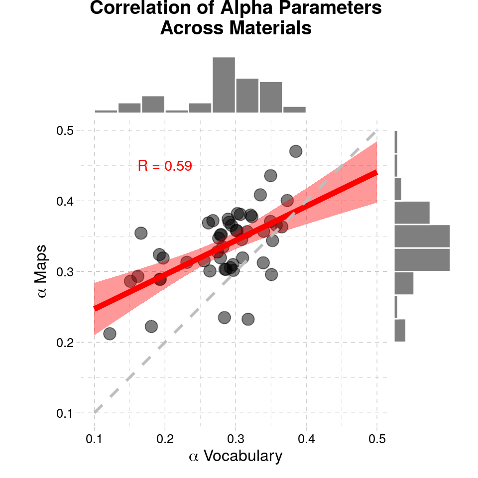

```r
p3 <- ggplot(wbehav, aes(x=Vocabulary, y=Maps)) +
  geom_point(size=4, alpha=0.5, col="black") + #col=K[7]) +
  geom_smooth(method = "lm", formula = y ~ x, col="red",
              fill="red", fullrange = T, lwd=2) +
  theme_pander() +
  scale_x_continuous() +
  scale_y_continuous() +
  coord_fixed() +
  ggtitle("Correlation of Alpha Parameters\nAcross Materials") +
  xlab(expression(paste(alpha, " Vocabulary"))) +
  ylab(expression(paste(alpha, " Maps"))) +
  annotate("segment", x=0.1, y=0.1, xend=0.5,
           yend=0.5, col="grey", lwd=1, lty=2) +
  annotate("text", label = paste("R =", round(cor(wbehav$Vocabulary,
                                                  wbehav$Maps),
                                              2)),
                                 x=0.2, y=0.45, col="red") +

  theme(plot.title = element_text(hjust = 0.5))

ggMarginal(p3, col="white", fill="black", alpha=0.5,
           type="hist", bins=13)
```

And here is a summary of the data:

```r
summary(wbehav) %>%
  xtable() %>%
  kable(digits = 3) %>%
  kable_styling(bootstrap_options = c("striped", "hover"))
```

| Subject | Gender | Age | Vocabulary | Maps |
| --- | --- | --- | --- | --- |
| Length:50 | Length:50 | Min. :18.00 | Min. :0.1219 | Min. :0.2120 |
| Class :character | Class :character | 1st Qu.:18.00 | 1st Qu.:0.2647 | 1st Qu.:0.3039 |
| Mode :character | Mode :character | Median :19.00 | Median :0.2917 | Median :0.3447 |
| NA | NA | Mean :18.88 | Mean :0.2825 | Mean :0.3355 |
| NA | NA | 3rd Qu.:19.00 | 3rd Qu.:0.3203 | 3rd Qu.:0.3680 |
| NA | NA | Max. :22.00 | Max. :0.3852 | Max. :0.4701 |
| NA | NA | NA’s :8 | NA | NA |

# Eyes-Closed EEG Data

Now we look at the neural correlates of the rates of forgetting in EEG data. We begin with *eyes closed* EEG data, which is the most common type of resting-state EEG recording.

## (Optional) Preprocess the Data

Set the `process_raw` variable to `TRUE` to reprocess the raw EEG data. That might take a **very** long time.

```r
process_raw = F
if (process_raw) {
  setwd("./data/eyes_closed/")
  for (sub in dir(grep("A[1-9]", dir()))) {
    setwd(sub)
    analyze.logfile(sub, "closed")
    setwd("..")
  }
  setwd("../..")
}
```

## Load the Eyes-Closed Spectra and Summary Files

The preprocessing step produces a number of text files. Here, we are interested in the *summary* file, which contains many useful statistics, including the Individual Alpha Frequency (i.e., the Alpha Peak) for each channel, the *spectra* file, which contains the estimated log power for each channel in increments of 0.5 Hz.

```r
ec_spectra <- NULL
for (sub in dir("data/eyes_closed/")[grep("A[1-9]",
                                        dir("data/eyes_closed/"))]) {
  table <- read_tsv(paste("data/eyes_closed/", sub, "/",
                          sub, "_closed_spectra.txt", sep=""),
                    col_types = cols())
  if (is.null(ec_spectra)) {
    ec_spectra <- table
  } else {
    ec_spectra <- ec_spectra %>% bind_rows(table)
  }
}

ec_summary <- NULL
for (sub in dir("data/eyes_closed/")[grep("A[1-9]",
                                          dir("data/eyes_closed/"))]) {
  table <- read_tsv(paste("data/eyes_closed/", sub, "/",
                          sub, "_closed_summary.txt", sep=""),
                    col_types = cols())
  if (is.null(ec_summary)) {
    ec_summary <- table
  } else {
    ec_summary <- ec_summary %>% bind_rows(table)
  }
}
```

### Individual Alpha frquency

The IAF is perhaps the most important subject level characteristic of the resting state spectrum. For this reason, we want to get some basic statistics. First, we calculate the subject-level IAF by computing the mode IAF across all channels for a given participant.

```r
iaf_cols <- paste(c("AF3", "AF4", "F3", "F4",
                    "F7", "F8", "FC5", "FC6",
                    "T7", "T8", "P7", "P8",
                    "O1", "O2"),
                  "IAF",
                  sep="_")

ec_iafs <- ec_summary %>%
  select(c("Subject", iaf_cols)) %>%
  filter(Subject %in% wbehav$Subject) %>%
  pivot_longer(cols = iaf_cols, names_sep="_",
               names_to = c("Channel", "Discard"),
               values_to = "IAF_EC") %>%
  select(Subject, Channel, IAF_EC) %>%
  group_by(Subject) %>%
  summarize(IAF_EC = Mode(IAF_EC))
```

[output not shown]

The mean IAF thus calculated is `10.3`, which is exactly in the middle of our alpha frequency band.

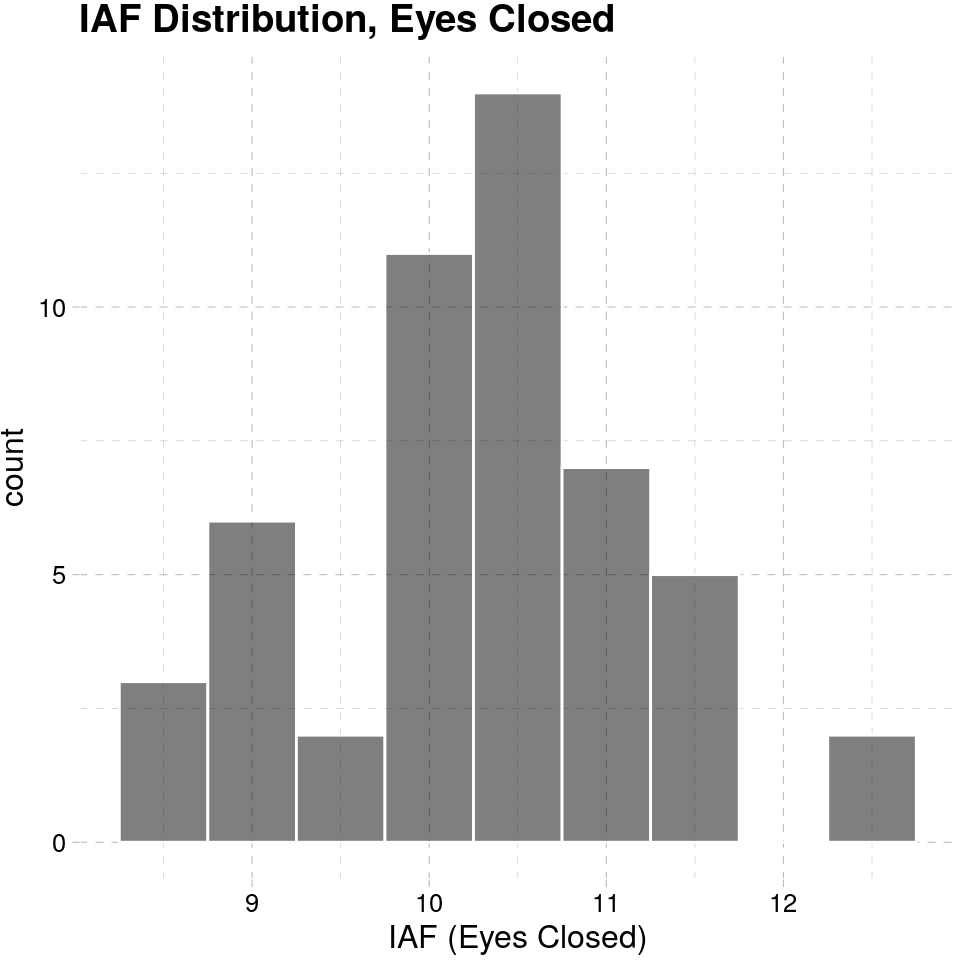

```r
ggplot(data=ec_iafs, aes(x = IAF_EC)) +
  geom_histogram(aes(col="white"), fill="black",
                 colour="white", alpha=0.5,
                 position="identity", binwidth = 0.5) +
  ggtitle("IAF Distribution, Eyes Closed") +
  xlab("IAF (Eyes Closed)") +
  theme_pander()
```

### Average Spectrum

First, let’s examine the spectrograms for each channel to make sure it looks normal and the IAF (individual alpha frequency) is reasonable, i.e., the same for each channel and roughly in the middle of the band definition

```r
l_ec_spectra <- pivot_longer(ec_spectra, cols=names(ec_spectra)[3:130],
                         names_to="Freq")

l_ec_spectra <- l_ec_spectra %>%
  rename(Power = value) %>%
  add_column(Recording = "Eyes Closed")

l_ec_spectra$Frequency <- as.numeric(substr(l_ec_spectra$Freq,
                                            0, str_length(l_ec_spectra$Freq) -2))
l_ec_spectra <- l_ec_spectra %>%
  add_column(Band="Delta", BandMin=0, BandMax=4)
l_ec_spectra$Band[l_ec_spectra$Frequency <= 40] <- "Gamma"
l_ec_spectra$Band[l_ec_spectra$Frequency < 30] <- "High Beta"
l_ec_spectra$Band[l_ec_spectra$Frequency < 18] <- "Upper Beta"
l_ec_spectra$Band[l_ec_spectra$Frequency < 15] <- "Low Beta"
l_ec_spectra$Band[l_ec_spectra$Frequency < 13] <- "Alpha"
l_ec_spectra$Band[l_ec_spectra$Frequency < 8] <- "Theta"
l_ec_spectra$Band[l_ec_spectra$Frequency < 4] <- "Delta"

l_ec_spectra$BandMin[l_ec_spectra$Frequency <= 40] <- 30
l_ec_spectra$BandMin[l_ec_spectra$Frequency < 30] <- 18
l_ec_spectra$BandMin[l_ec_spectra$Frequency < 18] <- 15
l_ec_spectra$BandMin[l_ec_spectra$Frequency < 15] <- 13
l_ec_spectra$BandMin[l_ec_spectra$Frequency < 13] <- 8
l_ec_spectra$BandMin[l_ec_spectra$Frequency < 8] <- 4
l_ec_spectra$BandMin[l_ec_spectra$Frequency < 4] <- 0

l_ec_spectra$BandMax[l_ec_spectra$Frequency <= 40] <- 40
l_ec_spectra$BandMax[l_ec_spectra$Frequency < 30] <- 30
l_ec_spectra$BandMax[l_ec_spectra$Frequency < 18] <- 18
l_ec_spectra$BandMax[l_ec_spectra$Frequency < 15] <- 15
l_ec_spectra$BandMax[l_ec_spectra$Frequency < 13] <- 13
l_ec_spectra$BandMax[l_ec_spectra$Frequency < 8] <- 8
l_ec_spectra$BandMax[l_ec_spectra$Frequency < 4] <- 4

l_ec_spectra$Band <- factor(l_ec_spectra$Band,
                        levels = c("Delta", "Theta", "Alpha",
                                   "Low Beta", "Upper Beta",
                                   "High Beta", "Gamma"))
```

Now, we remove the three participants for which we have poor quality data

```r
l_ec_spectra <- l_ec_spectra %>%
  filter(Subject %in% behav$Subject)
```

We can visualize the power spectra to ensure that our data looks normal

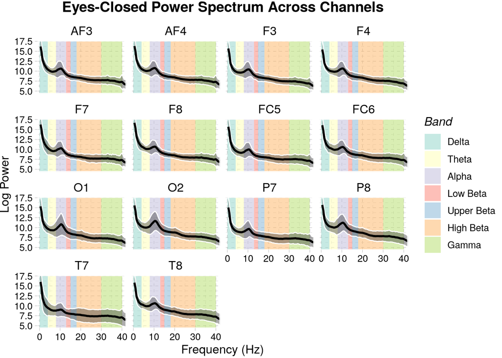

```r
gd <- l_ec_spectra %>%
        group_by(Band) %>%
        summarise(
          Min = mean(BandMin),
          Max = mean(BandMax),
          Power =mean(Power),
          Frequency = mean(BandMin)
          #Channel=
        )

ggplot(data=l_ec_spectra, aes(x=Frequency, y=Power, Channel)) +
  geom_rect(data = gd, aes(xmin = Min, xmax = Max, fill = Band),
            ymin=0, ymax=Inf, colour=NA, alpha=0.5) +
  stat_summary(fun.data=mean_sdl,
               geom = "ribbon", colour = "white", alpha = 0.4) +
  stat_summary(fun = mean, geom = "line", lwd = 1) +
  facet_wrap(~ Channel, ncol=4) +
  scale_alpha_manual(values = seq(0.1, 0.9, 0.1)) +
  ggtitle("Eyes-Closed Power Spectrum Across Channels") +
  ylab("Log Power") +
  xlab("Frequency (Hz)") +
  theme_pander() +
  coord_cartesian(xlim=c(1,40), ylim=c(5, 17)) + #ylim=c(5,17)) +
  scale_fill_brewer(palette = "Set3") +
  theme(plot.title = element_text(hjust = 0.5))
```

Now, let’s create a mean spectrogram with annotations that mark the different frequency bands. It serves as a visual reference that our data is not grossly out of whack.

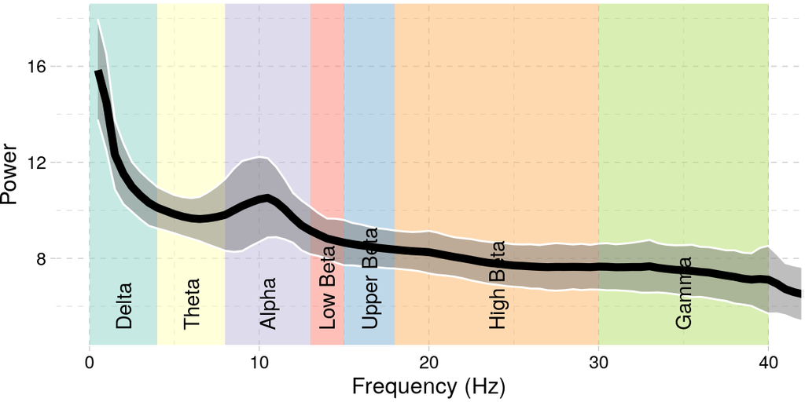

```r
K = brewer.pal(7, "Set3")

al_ec_spectra <- aggregate(l_ec_spectra[c("Power")],
                       list(Subject = l_ec_spectra$Subject,
                            Frequency = l_ec_spectra$Frequency,
                            Band = l_ec_spectra$Band),
                       mean)

ggplot(data=al_ec_spectra, aes(x=Frequency, y=Power, col=Power)) +
  annotate("rect", xmin = 0, xmax = 4, ymin = 0, ymax = Inf,
           alpha = 0.5, fill=K[1]) +
  annotate("rect", xmin = 4, xmax = 8, ymin = 0, ymax = Inf,
           alpha = 0.5, fill=K[2]) +
  annotate("rect", xmin = 8, xmax = 13, ymin = 0, ymax = Inf,
           alpha = 0.5, fill=K[3]) +
  annotate("rect", xmin = 13, xmax = 15, ymin = 0, ymax = Inf,
           alpha = 0.5, fill=K[4]) +
  annotate("rect", xmin = 15, xmax = 18, ymin = 0, ymax = Inf,
           alpha = 0.5, fill = K[5]) +
  annotate("rect", xmin = 18, xmax = 30, ymin = 0, ymax = Inf,
           alpha = 0.5, fill=K[6]) +
  annotate("rect", xmin = 30, xmax = 40, ymin = 0, ymax = Inf,
           alpha = 0.5, fill=K[7]) +
  stat_summary(fun.data = mean_sdl, geom = "ribbon",
               alpha = 0.5, fill = "grey50", col = "white") +
  stat_summary(fun=mean, geom="line", lwd=2) +
  coord_cartesian(xlim=c(0,40), ylim=c(5,18)) +
  xlab("Frequency (Hz)") +
  theme_pander() +
  annotate("text", x=2, y=5, label="Delta", angle=90, hjust=0) +
  annotate("text", x=6, y=5, label="Theta", angle=90, hjust=0) +
  annotate("text", x=10.5, y=5, label="Alpha", angle=90, hjust=0) +
  annotate("text", x=14, y=5, label="Low Beta", angle=90, hjust=0) +
  annotate("text", x=16.5, y=5, label="Upper Beta", angle=90, hjust=0) +
  annotate("text", x=24, y=5, label="High Beta", angle=90, hjust=0) +
  annotate("text", x=35, y=5, label="Gamma", angle=90, hjust=0)
```

## Correlations with Rate of Forgetting

Having ensured that our EEG recordings look normal, reflect known neurophysiological characteristics, and that our frequency bands boundaries are reasonable, we can proceed with correlating the rates of forgetting with resting state QEEG characteristics.

First, we calculate the mean power for every band and channel, remove participants who were not included in the behavioral tests, and correct for multiple comparisons by frequency band:

```r
wbehav <- wbehav %>%
  mutate(GlobalAlpha=(Vocabulary + Maps)/2)

Adata <- l_ec_spectra %>%
  group_by(Subject, Channel, Band, Recording) %>%
  summarize(Power=mean(Power))

Fdata <- inner_join(Adata, behav, by="Subject")

Rdata <- Fdata %>%
  group_by(material, Channel, Band, Recording) %>%
  summarise(r = cor(Power, alpha),
            p = cor.test(Power, alpha)$p.value)

Rdata <- Rdata %>%
  group_by(material, Band, Recording) %>%
  mutate(q = p.adjust(p, method="BH"))
```

Here is the full table of statistics:

```r
write_csv(Rdata, "correlations_channel_band_eyes_closed.csv", col_names = T)
Rdata %>%
  xtable() %>%
  kable(digits = 3) %>%
  kable_styling(bootstrap_options = c("striped", "hover"))
```

| material | Channel | Band | Recording | r | p | q |
| --- | --- | --- | --- | --- | --- | --- |
| Maps | AF3 | Delta | Eyes Closed | 0.010 | 0.947 | 0.971 |
| Maps | AF3 | Theta | Eyes Closed | 0.072 | 0.621 | 0.790 |
| Maps | AF3 | Alpha | Eyes Closed | 0.113 | 0.436 | 0.592 |
| Maps | AF3 | Low Beta | Eyes Closed | 0.189 | 0.188 | 0.316 |
| Maps | AF3 | Upper Beta | Eyes Closed | 0.314 | 0.026 | 0.092 |
| Maps | AF3 | High Beta | Eyes Closed | 0.219 | 0.127 | 0.403 |
| Maps | AF3 | Gamma | Eyes Closed | 0.101 | 0.484 | 0.924 |
| Maps | AF4 | Delta | Eyes Closed | 0.096 | 0.507 | 0.971 |
| Maps | AF4 | Theta | Eyes Closed | 0.079 | 0.585 | 0.790 |
| Maps | AF4 | Alpha | Eyes Closed | 0.147 | 0.308 | 0.582 |
| Maps | AF4 | Low Beta | Eyes Closed | 0.216 | 0.132 | 0.316 |
| Maps | AF4 | Upper Beta | Eyes Closed | 0.339 | 0.016 | 0.092 |
| Maps | AF4 | High Beta | Eyes Closed | 0.280 | 0.049 | 0.342 |
| Maps | AF4 | Gamma | Eyes Closed | 0.145 | 0.315 | 0.924 |
| Maps | F3 | Delta | Eyes Closed | -0.005 | 0.971 | 0.971 |
| Maps | F3 | Theta | Eyes Closed | 0.072 | 0.619 | 0.790 |
| Maps | F3 | Alpha | Eyes Closed | 0.140 | 0.333 | 0.582 |
| Maps | F3 | Low Beta | Eyes Closed | 0.183 | 0.203 | 0.316 |
| Maps | F3 | Upper Beta | Eyes Closed | 0.256 | 0.073 | 0.120 |
| Maps | F3 | High Beta | Eyes Closed | 0.184 | 0.200 | 0.403 |
| Maps | F3 | Gamma | Eyes Closed | 0.022 | 0.881 | 0.924 |
| Maps | F4 | Delta | Eyes Closed | 0.239 | 0.095 | 0.343 |
| Maps | F4 | Theta | Eyes Closed | 0.122 | 0.400 | 0.790 |
| Maps | F4 | Alpha | Eyes Closed | 0.156 | 0.278 | 0.582 |
| Maps | F4 | Low Beta | Eyes Closed | 0.200 | 0.164 | 0.316 |
| Maps | F4 | Upper Beta | Eyes Closed | 0.290 | 0.041 | 0.116 |
| Maps | F4 | High Beta | Eyes Closed | 0.215 | 0.133 | 0.403 |
| Maps | F4 | Gamma | Eyes Closed | 0.135 | 0.349 | 0.924 |
| Maps | F7 | Delta | Eyes Closed | -0.058 | 0.689 | 0.971 |
| Maps | F7 | Theta | Eyes Closed | 0.087 | 0.550 | 0.790 |

[output cut: 166 more lines]

And here is the corresponding distributions of *r* and *p* values. The dashed lines correspond to a significant threshold of *p* < .05 on either a *r* or a *p*-value scale.

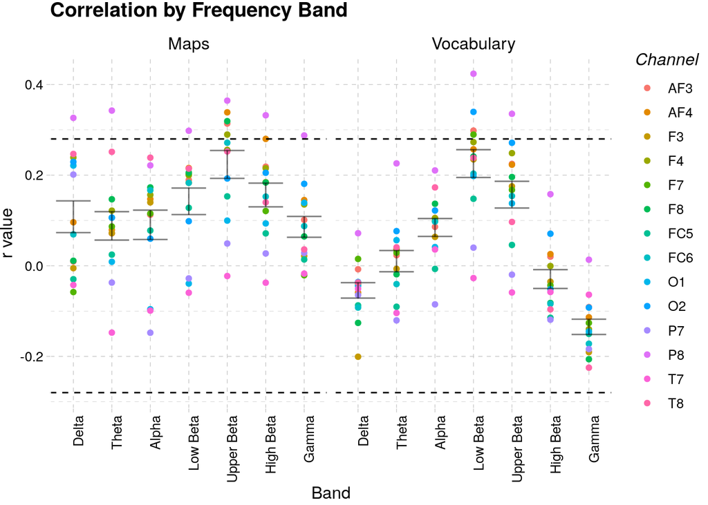

```r
ggplot(Rdata, aes(x = Band, y = r, col = Channel)) +
  geom_point() +
  stat_summary(fun.data = "mean_se", col="black",
               alpha=0.5, geom = "errorbar") +
  facet_wrap(~ material) +
  ggtitle("Correlation by Frequency Band") +
  ylab("r value") +
  annotate("segment", x=-Inf, xend=Inf, y=0.28, yend = 0.28, lty=2) +
  annotate("segment", x=-Inf, xend=Inf, y=-0.28, yend = -0.28, lty=2) +
  theme(axis.text.x = element_text(angle = 90, hjust = 1)) +
  theme_pander()
```

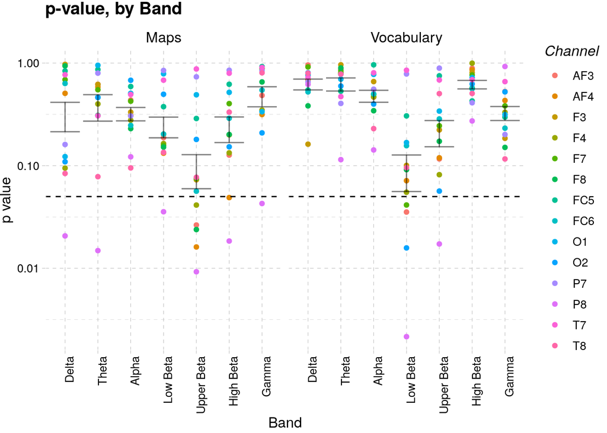

```r
ggplot(Rdata, aes(x = Band, y = p, col = Channel)) +
  geom_point() +
  stat_summary(fun.data = "mean_se", col="black", alpha=0.5, geom = "errorbar") +
  ggtitle("p-value, by Band") +
  ylab("p value") +
  facet_wrap(~ material) +
  annotate("segment", x=-Inf, xend=Inf, y=0.05, yend = 0.05, lty=2) +
  theme(axis.text.x = element_text(angle = 90, hjust = 1)) +
  scale_y_log10() +
  theme_pander()
```

From the original list, we can extract only those channels that survive the FDR correction:

```r
survivors <- Rdata %>%
  filter(q < 0.05)

survivors %>%
  xtable() %>%
  kable(digits = 3) %>%
  kable_styling(bootstrap_options = c("striped", "hover"))
```

| material | Channel | Band | Recording | r | p | q |
| --- | --- | --- | --- | --- | --- | --- |
| Vocabulary | P8 | Low Beta | Eyes Closed | 0.424 | 0.002 | 0.03 |

Only one channel P8, in one frequency band (low beta) survives FDR correction. We can plot the correlation between power in P8 and rate of forgetting to see the relationship:

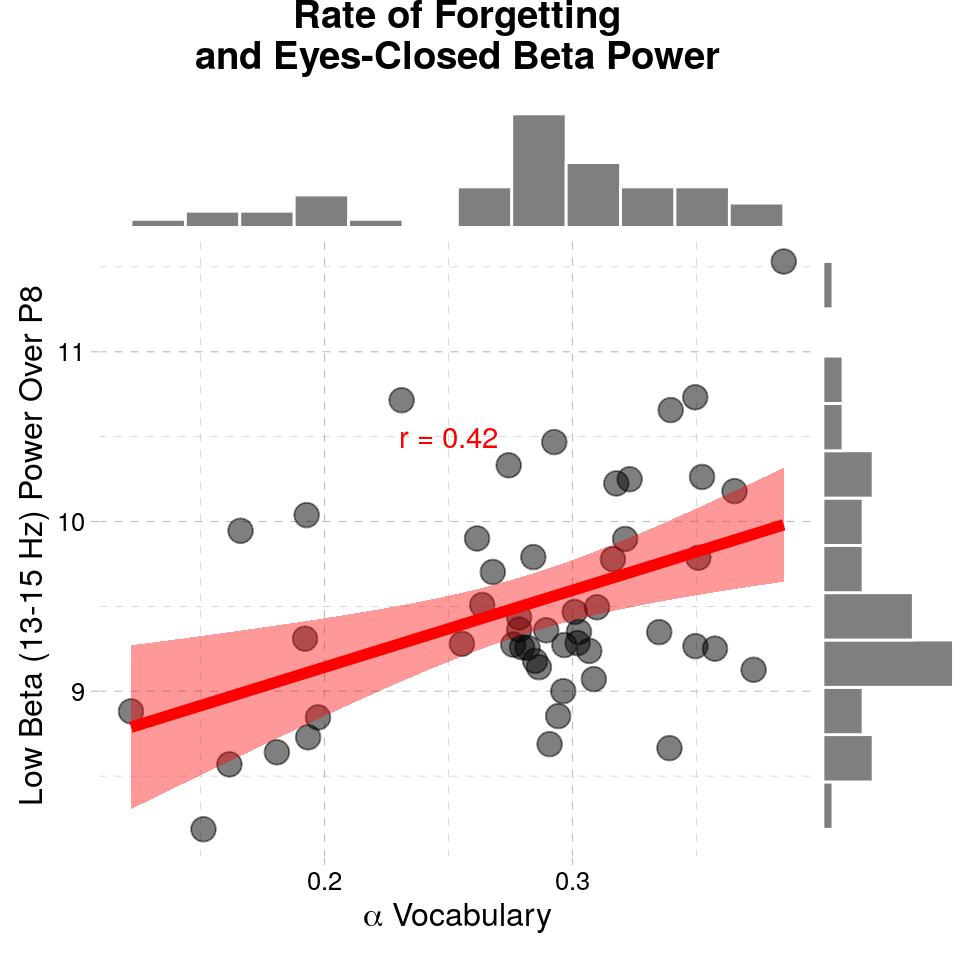

```r
focus <- Fdata %>%
  filter(material == "Vocabulary",
         Channel %in% survivors$Channel,
         Band == "Low Beta") %>%
  rename(Alpha = alpha)

p<-ggplot(focus, aes(x=Alpha, y=Power)) +
  geom_point(size=4, alpha=0.5, col="black") +
  geom_smooth(method = "lm", formula = y ~ x,
              col="red", fill="red", fullrange = T, lwd=2) +
  theme_pander() +
  scale_x_continuous() +
  scale_y_continuous() +
  ggtitle("Rate of Forgetting\nand Eyes-Closed Beta Power") +
  xlab(expression(paste(alpha, " Vocabulary"))) +
  ylab("Low Beta (13-15 Hz) Power Over P8") +
  geom_text(data=survivors, col="red",
            mapping=aes(x=0.25, y=10.5,
                        label= paste("r =", round(r, 2)))) +
  theme(plot.title = element_text(hjust = 0.5))

ggMarginal(p, col="white", fill="black", alpha=0.5,
           type="hist", bins=13)
```

# Eyes-Open EEG Data

## (Optional) Preprocess the Data

Set the `process_raw` variable to `TRUE` to reprocess the raw EEG data. That might take a **very** long time.

```r
process_raw = F
if (process_raw) {
  setwd("eyes_open/")
  for (sub in dir(grep("A[1-9]", dir()))) {
    setwd(sub)
    analyze.logfile(sub, "open")
    setwd("..")
  }
  setwd("..")
}
```

## Load the Eyes-Open Spectra and Summary Files

As in the case of eyes-closed data, we are going to examine the spectral and IAF characteristics of eyes-open recordings though the *summary* files produced by preprocessing.

```r
eo_spectra <- NULL
for (sub in dir("data/eyes_open/")[grep("A[1-9]",
                                        dir("data/eyes_open/"))]) {
  table <- read_tsv(paste("data/eyes_open/", sub, "/",
                          sub, "_open_spectra.txt", sep=""),
                    col_types = cols())
  if (is.null(eo_spectra)) {
    eo_spectra <- table
  } else {
    eo_spectra <- eo_spectra %>% bind_rows(table)
  }
}

eo_summary <- NULL
for (sub in dir("data/eyes_open/")[grep("A[1-9]",
                                        dir("data/eyes_open/"))]) {
  table <- read_tsv(paste("data/eyes_open/", sub, "/",
                          sub, "_open_summary.txt", sep=""),
                    col_types = cols())
  if (is.null(eo_summary)) {
    eo_summary <- table
  } else {
    eo_summary <- eo_summary %>% bind_rows(table)
  }
}
```

### Individual Alpha frquency

Since eyes-open recordings are somewhat less common, we need to run a few sanity checks on them. The first and most obsvious concerns the IAF, and whether the IAFs during eyes-open recordings are similar and correlated to those observed during eyes-closed sessions.

```r
eo_iafs <- eo_summary %>%
  select(c("Subject", iaf_cols)) %>%
  filter(Subject %in% wbehav$Subject) %>%
  pivot_longer(cols = iaf_cols, names_sep="_",
               names_to = c("Channel", "Discard"),
               values_to = "IAF_EO") %>%
  select(Subject, Channel, IAF_EO) %>%
  group_by(Subject) %>%
  summarize(IAF_EO = Mode(IAF_EO))

iafs <- inner_join(eo_iafs, ec_iafs, by="Subject")
```

The mean IAF thus calculated is `10.33`, which is, once more, exactly in the middle of our alpha frequency band.

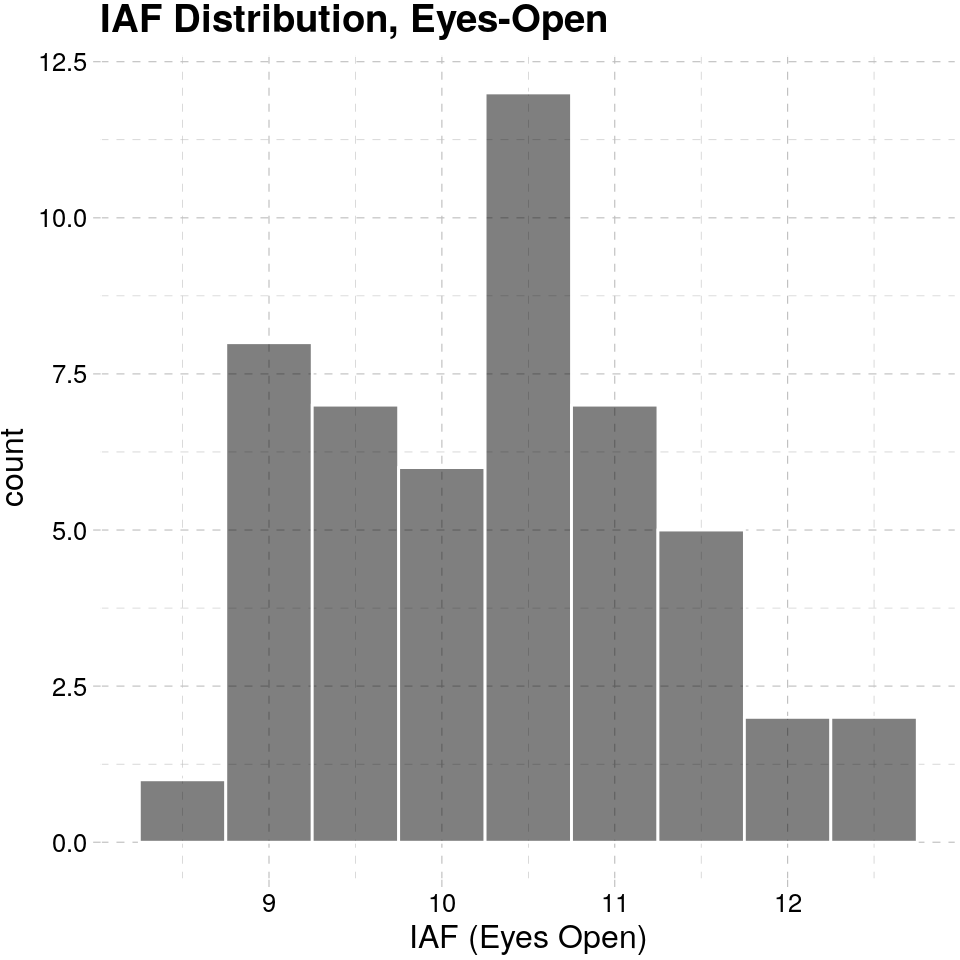

```r
ggplot(data=eo_iafs, aes(x = IAF_EO)) +
  geom_histogram(aes(col="white"), fill="black",
                 colour="white", alpha=0.5,
                 position="identity", binwidth = 0.5) +
  ggtitle("IAF Distribution, Eyes-Open") +
  xlab("IAF (Eyes Open)") +
  theme_pander()
```

As it can be seen, there is a significant correlation in the IAFs between the two recordings (*p* = `10^{-6}`). Between recordings, the individual IAF remains the same +/- `0.83`.

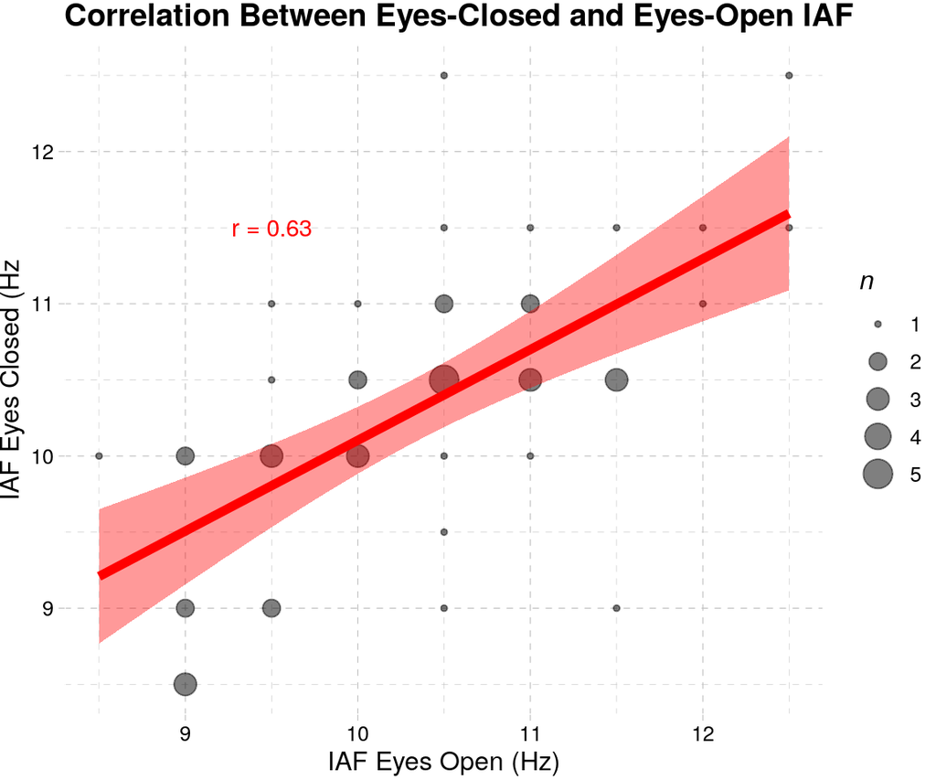

```r
ggplot(iafs, aes(x=IAF_EO, y=IAF_EC)) +
  geom_count(alpha=0.5, col="black") +
  geom_smooth(method = "lm", formula = y ~ x,
              col="red", fill="red", fullrange = T, lwd=2) +
  xlab("IAF Eyes Open (Hz)") +
  ylab("IAF Eyes Closed (Hz") +
  geom_text(data = summarize(iafs, Mean=mean(IAF_EC)),  # Avoid label overlaps
            x= 9.5, y=11.5,
            col="red",
            label=paste("r =",
                        round(cor(iafs$IAF_EC, iafs$IAF_EO), 2))) +
  ggtitle("Correlation Between Eyes-Closed and Eyes-Open IAF") +
  theme_pander()
```

### Average Spectrum

We can also investigate whether the average spectrum is comparable to that of eyes-closed recordings. To do so, we will calculate the average spectrum across channels, much in the same ways as it was done for eyes-closed data:

```r
l_eo_spectra <- pivot_longer(eo_spectra, cols=names(ec_spectra)[3:130],
                         names_to="Freq")

l_eo_spectra <- l_eo_spectra %>%
  rename(Power = value) %>%
  add_column(Recording = "Eyes Open")

l_eo_spectra$Frequency <- as.numeric(substr(l_eo_spectra$Freq,
                                            0, str_length(l_eo_spectra$Freq) -2))
l_eo_spectra <- l_eo_spectra %>%
  add_column(Band="Delta", BandMin=0, BandMax=4)
l_eo_spectra$Band[l_eo_spectra$Frequency <= 40] <- "Gamma"
l_eo_spectra$Band[l_eo_spectra$Frequency < 30] <- "High Beta"
l_eo_spectra$Band[l_eo_spectra$Frequency < 18] <- "Upper Beta"
l_eo_spectra$Band[l_eo_spectra$Frequency < 15] <- "Low Beta"
l_eo_spectra$Band[l_eo_spectra$Frequency < 13] <- "Alpha"
l_eo_spectra$Band[l_eo_spectra$Frequency < 8] <- "Theta"
l_eo_spectra$Band[l_eo_spectra$Frequency < 4] <- "Delta"

l_eo_spectra$BandMin[l_eo_spectra$Frequency <= 40] <- 30
l_eo_spectra$BandMin[l_eo_spectra$Frequency < 30] <- 18
l_eo_spectra$BandMin[l_eo_spectra$Frequency < 18] <- 15
l_eo_spectra$BandMin[l_eo_spectra$Frequency < 15] <- 13
l_eo_spectra$BandMin[l_eo_spectra$Frequency < 13] <- 8
l_eo_spectra$BandMin[l_eo_spectra$Frequency < 8] <- 4
l_eo_spectra$BandMin[l_eo_spectra$Frequency < 4] <- 0

l_eo_spectra$BandMax[l_eo_spectra$Frequency <= 40] <- 40
l_eo_spectra$BandMax[l_eo_spectra$Frequency < 30] <- 30
l_eo_spectra$BandMax[l_eo_spectra$Frequency < 18] <- 18
l_eo_spectra$BandMax[l_eo_spectra$Frequency < 15] <- 15
l_eo_spectra$BandMax[l_eo_spectra$Frequency < 13] <- 13
l_eo_spectra$BandMax[l_eo_spectra$Frequency < 8] <- 8
l_eo_spectra$BandMax[l_eo_spectra$Frequency < 4] <- 4

l_eo_spectra$Band <- factor(l_eo_spectra$Band,
                        levels = c("Delta", "Theta", "Alpha",
                                   "Low Beta", "Upper Beta",
                                   "High Beta", "Gamma"))
```

Now, we remove the three participants for which we have poor quality data

```r
l_eo_spectra <- l_eo_spectra %>%
  filter(Subject %in% behav$Subject)
```

And we can visualize the eyes-open power spectra by channel:

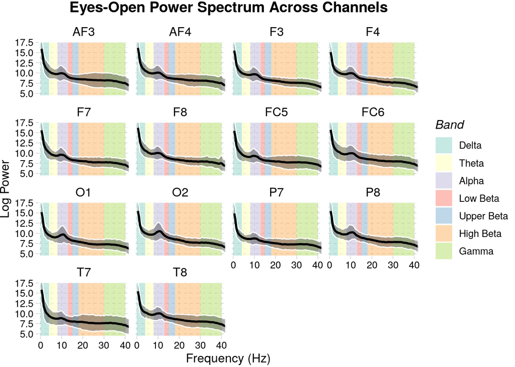

```r
gd <- l_eo_spectra %>%
        group_by(Band) %>%
        summarise(
          Min = mean(BandMin),
          Max = mean(BandMax),
          Power =mean(Power),
          Frequency = mean(BandMin)
        )

ggplot(data=l_eo_spectra, aes(x=Frequency, y=Power, Channel)) +
  geom_rect(data = gd, aes(xmin = Min, xmax = Max, fill = Band),
            ymin=0, ymax=Inf, colour=NA, alpha=0.5) +
  stat_summary(fun.data=mean_sdl,
               geom = "ribbon", colour = "white", alpha = 0.4) +
  stat_summary(fun = mean, geom = "line", lwd = 1) +
  facet_wrap(~ Channel, ncol=4) +
  scale_alpha_manual(values = seq(0.1, 0.9, 0.1)) +
  ggtitle("Eyes-Open Power Spectrum Across Channels") +
  ylab("Log Power") +
  xlab("Frequency (Hz)") +
  theme_pander() +
  coord_cartesian(xlim=c(1,40), ylim=c(5, 17)) + #ylim=c(5,17)) +
  scale_fill_brewer(palette = "Set3") +
  theme(plot.title = element_text(hjust = 0.5))
```

At a first sight, the eyes-open power spectrum looks remarkably similar, with the obvious (and expected) difference of a less prominent pean in the alpha band. To better compare the two types of recordings, we can visualize the avearage spectra on top of ech other:

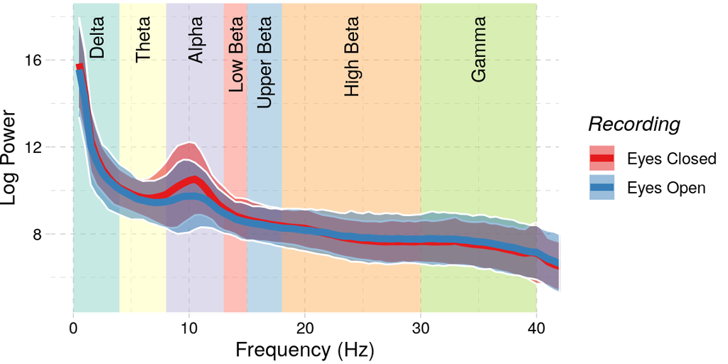

```r
l_spectra <- rbind(l_ec_spectra, l_eo_spectra)

al_spectra <- l_spectra %>%
  group_by(Subject, Frequency, Band, Recording) %>%
  summarise(Power = mean(Power))

al_spectra <- al_spectra %>% ungroup()

ggplot(data=al_spectra, aes(x = Frequency, y = Power,
                            col = Recording, fill = Recording)) +
  annotate("rect", xmin = 0, xmax = 4, ymin = 0, ymax = Inf,
           alpha = 0.5, fill=K[1]) +
  annotate("rect", xmin = 4, xmax = 8, ymin = 0, ymax = Inf,
           alpha = 0.5, fill=K[2]) +
  annotate("rect", xmin = 8, xmax = 13, ymin = 0, ymax = Inf,
           alpha = 0.5, fill=K[3]) +
  annotate("rect", xmin = 13, xmax = 15, ymin = 0, ymax = Inf,
           alpha = 0.5, fill=K[4]) +
  annotate("rect", xmin = 15, xmax = 18, ymin = 0, ymax = Inf,
           alpha = 0.5, fill = K[5]) +
  annotate("rect", xmin = 18, xmax = 30, ymin = 0, ymax = Inf,
           alpha = 0.5, fill=K[6]) +
  annotate("rect", xmin = 30, xmax = 40, ymin = 0, ymax = Inf,
           alpha = 0.5, fill=K[7]) +
  stat_summary(fun.data = mean_sdl, geom = "ribbon",
               alpha = 0.5, col = "white") +
  scale_color_brewer(palette = "Set1") +
  scale_fill_brewer(palette = "Set1") +
  stat_summary(fun = mean, geom = "line", lwd = 2) +
  coord_cartesian(xlim=c(0,40), ylim=c(5,18)) +
  xlab("Frequency (Hz)") +
  ylab("Log Power") +
  theme_pander() +
  annotate("text", x=2, y=18, label="Delta", angle=90, hjust=1) +
  annotate("text", x=6, y=18, label="Theta", angle=90, hjust=1) +
  annotate("text", x=10.5, y=18, label="Alpha", angle=90, hjust=1) +
  annotate("text", x=14, y=18, label="Low Beta", angle=90, hjust=1) +
  annotate("text", x=16.5, y=18, label="Upper Beta", angle=90, hjust=1) +
  annotate("text", x=24, y=18, label="High Beta", angle=90, hjust=1) +
  annotate("text", x=35, y=18, label="Gamma", angle=90, hjust=1)
```

## Correlations with Rate of Forgetting

Like we did for eyes-closed data, we can now calculate the correlations between eyes-open EEG power spectra and the behavioral rate fo forgetting for verbal and visual materials.

```r
wbehav <- wbehav %>%
  mutate(GlobalAlpha=(Vocabulary + Maps) / 2)

Adata <- l_eo_spectra %>%
  group_by(Subject, Channel, Band, Recording) %>%
  summarize(Power=mean(Power))

Fdata <- inner_join(Adata, behav, by = "Subject")

Cdata <- Fdata %>%
  group_by(material, Channel, Band, Recording) %>%
  summarise(r = cor(Power, alpha),
            p = cor.test(Power, alpha)$p.value)

Rdata <- Cdata %>%
  group_by(material, Band, Recording) %>%
  mutate(q = p.adjust(p, method="BH"))
```

We save the data so that it can be visualized as a topomao with Python MNE. Here is the full table of statistics:

```r
write_csv(Rdata, "correlations_channel_band_eyes_open.csv", col_names = T)
Rdata %>%
  xtable() %>%
  kable(digits = 3) %>%
  kable_styling(bootstrap_options = c("striped", "hover"))
```

| material | Channel | Band | Recording | r | p | q |
| --- | --- | --- | --- | --- | --- | --- |
| Maps | AF3 | Delta | Eyes Open | 0.180 | 0.211 | 0.686 |
| Maps | AF3 | Theta | Eyes Open | 0.122 | 0.397 | 0.556 |
| Maps | AF3 | Alpha | Eyes Open | 0.218 | 0.129 | 0.200 |
| Maps | AF3 | Low Beta | Eyes Open | 0.255 | 0.074 | 0.206 |
| Maps | AF3 | Upper Beta | Eyes Open | 0.383 | 0.006 | 0.021 |
| Maps | AF3 | High Beta | Eyes Open | 0.279 | 0.050 | 0.140 |
| Maps | AF3 | Gamma | Eyes Open | 0.236 | 0.100 | 0.447 |
| Maps | AF4 | Delta | Eyes Open | 0.141 | 0.330 | 0.686 |
| Maps | AF4 | Theta | Eyes Open | 0.136 | 0.347 | 0.540 |
| Maps | AF4 | Alpha | Eyes Open | 0.247 | 0.083 | 0.184 |
| Maps | AF4 | Low Beta | Eyes Open | 0.301 | 0.034 | 0.206 |
| Maps | AF4 | Upper Beta | Eyes Open | 0.383 | 0.006 | 0.021 |
| Maps | AF4 | High Beta | Eyes Open | 0.315 | 0.026 | 0.140 |
| Maps | AF4 | Gamma | Eyes Open | 0.256 | 0.073 | 0.447 |
| Maps | F3 | Delta | Eyes Open | 0.065 | 0.656 | 0.707 |
| Maps | F3 | Theta | Eyes Open | 0.246 | 0.085 | 0.441 |
| Maps | F3 | Alpha | Eyes Open | 0.232 | 0.105 | 0.184 |
| Maps | F3 | Low Beta | Eyes Open | 0.221 | 0.122 | 0.244 |
| Maps | F3 | Upper Beta | Eyes Open | 0.326 | 0.021 | 0.037 |
| Maps | F3 | High Beta | Eyes Open | 0.219 | 0.126 | 0.253 |
| Maps | F3 | Gamma | Eyes Open | 0.126 | 0.384 | 0.662 |
| Maps | F4 | Delta | Eyes Open | 0.103 | 0.478 | 0.686 |
| Maps | F4 | Theta | Eyes Open | 0.236 | 0.099 | 0.441 |
| Maps | F4 | Alpha | Eyes Open | 0.248 | 0.082 | 0.184 |
| Maps | F4 | Low Beta | Eyes Open | 0.265 | 0.063 | 0.206 |
| Maps | F4 | Upper Beta | Eyes Open | 0.338 | 0.016 | 0.034 |
| Maps | F4 | High Beta | Eyes Open | 0.294 | 0.038 | 0.140 |
| Maps | F4 | Gamma | Eyes Open | 0.204 | 0.154 | 0.447 |
| Maps | F7 | Delta | Eyes Open | 0.233 | 0.104 | 0.686 |
| Maps | F7 | Theta | Eyes Open | 0.148 | 0.304 | 0.540 |

[output cut: 166 more lines]

And here is the corresponding distributions of *r* and *p* values. The dashed lines correspond to a significant threshold of *p* < .05 on either a *r* or a *p*-value scale.

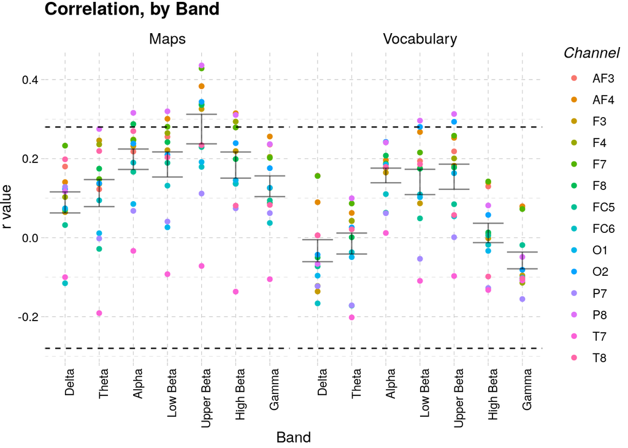

```r
ggplot(Cdata, aes(x=Band, y=r, col=Channel)) +
  geom_point() +
  stat_summary(fun.data = "mean_se", col="black",
               alpha=0.5, geom = "errorbar") +
  facet_wrap(~ material) +
  ggtitle("Correlation, by Band") +
  ylab("r value") +
  annotate("segment", x=-Inf, xend=Inf, y=0.28, yend = 0.28, lty=2) +
  annotate("segment", x=-Inf, xend=Inf, y=-0.28, yend = -0.28, lty=2) +
  theme(axis.text.x = element_text(angle = 90, hjust = 1)) +
  theme_pander()
```

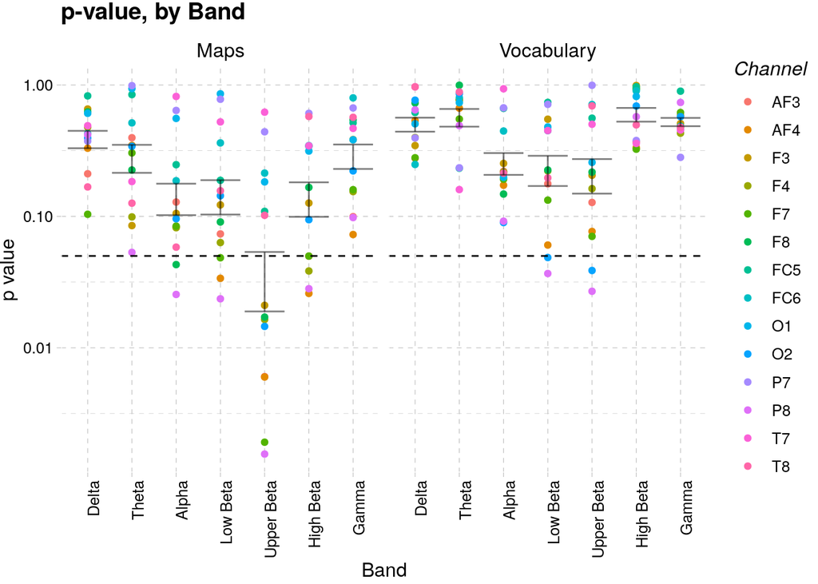

```r
ggplot(Cdata, aes(x=Band, y=p, col=Channel)) +
  geom_point() +
  stat_summary(fun.data = "mean_se", col="black",
               alpha=0.5, geom = "errorbar") +
  ggtitle("p-value, by Band") +
  ylab("p value") +
  facet_wrap(~ material) +
  annotate("segment", x=-Inf, xend=Inf, y=0.05, yend = 0.05, lty=2) +
  theme(axis.text.x = element_text(angle = 90, hjust = 1)) +
  scale_y_log10() +
  theme_pander()
```

Let’s tabulate only those channels that survive the FDR correction:

```r
survivors <- Rdata %>%
  filter(q < 0.05)

survivors %>%
  xtable() %>%
  kable(digits = 3) %>%
  kable_styling(bootstrap_options = c("striped", "hover"))
```

| material | Channel | Band | Recording | r | p | q |
| --- | --- | --- | --- | --- | --- | --- |
| Maps | AF3 | Upper Beta | Eyes Open | 0.383 | 0.006 | 0.021 |
| Maps | AF4 | Upper Beta | Eyes Open | 0.383 | 0.006 | 0.021 |
| Maps | F3 | Upper Beta | Eyes Open | 0.326 | 0.021 | 0.037 |
| Maps | F4 | Upper Beta | Eyes Open | 0.338 | 0.016 | 0.034 |
| Maps | F7 | Upper Beta | Eyes Open | 0.428 | 0.002 | 0.013 |
| Maps | F8 | Upper Beta | Eyes Open | 0.336 | 0.017 | 0.034 |
| Maps | O2 | Upper Beta | Eyes Open | 0.344 | 0.015 | 0.034 |
| Maps | P8 | Upper Beta | Eyes Open | 0.436 | 0.002 | 0.013 |

In the case of eyes-open data, we have a much larger set of channels that survive correction for multiple comparison. Although these correlations generally reflect the same trends we have seen the eyes-closed data (i.e., significant positive correlations for prefrontal and right parietal sites), they are now stroger for *visual* (not *verbal*) materials and centered at at slightly higher frequency (upper beta instead of low beta).

Here is an overview of the scatterplots and correlations:

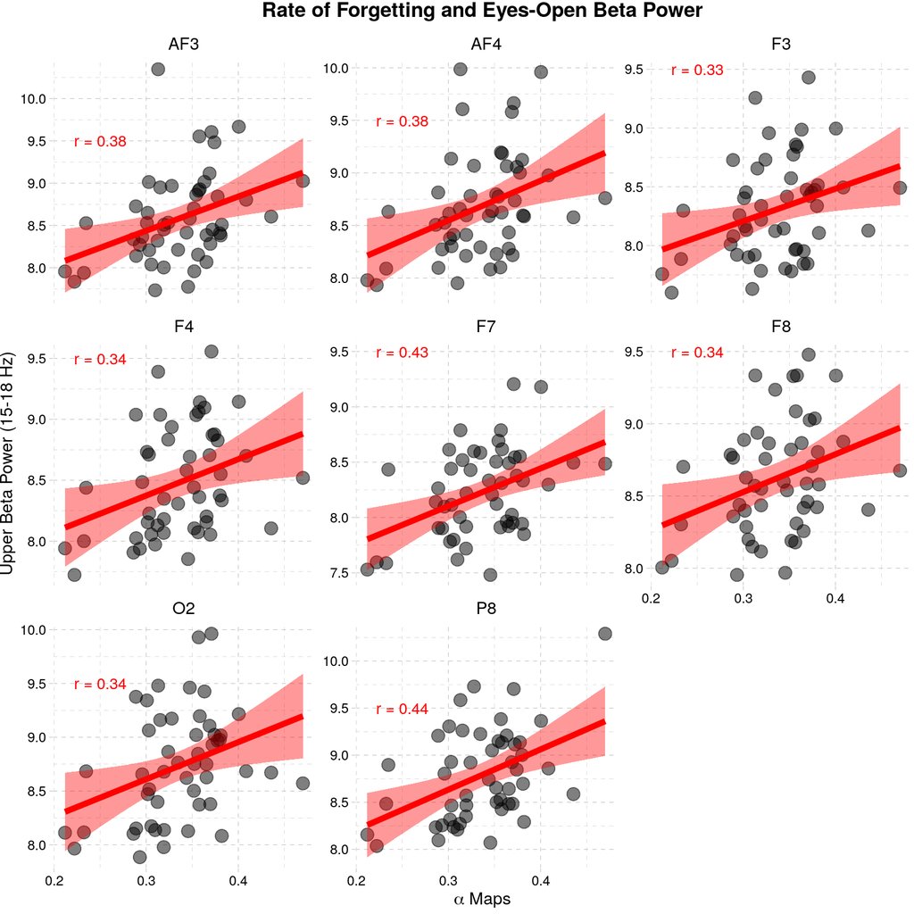

```r
focus <- Fdata %>%
  filter(material == "Maps",
         Channel %in% survivors$Channel,
         Band == "Upper Beta") %>%
  rename(Alpha = alpha)

ggplot(focus, aes(x=Alpha, y=Power)) +
  geom_point(size=4, alpha=0.5, col="black") +
  geom_smooth(method = "lm", formula = y ~ x,
              col="red", fill="red", fullrange = T, lwd=2) +
  theme_pander() +
  scale_x_continuous() +
  scale_y_continuous() +
  ggtitle("Rate of Forgetting and Eyes-Open Beta Power") +
  xlab(expression(paste(alpha, " Maps"))) +
  ylab("Upper Beta Power (15-18 Hz)") +
  facet_wrap(~ Channel, scales="free_y") +
  geom_text(data=survivors, col="red",
            mapping=aes(x=0.25, y=9.5,
                        label= paste("r =", round(r, 2)))) +
  theme(plot.title = element_text(hjust = 0.5))
```